# Modelo SARIMA: Caso Spotify 2016-2025

Julian Echeverry - MINE 009

2026-03-07

[figure not shown]

# Introducción

En el presente ejercicio se busca aplicar el algoritmo Box-Jenkins para generar un modelo SARIMA que permita predecir el *número total trimestral de usuarios de Spotify (en millones) en la región de Latinoamérica*.

La serie tiene una frecuencia trimestral para el período entre 2016-I y 2025-III. Por otra parte, las cifras incluyen a los usuarios de las categorías pagas (premium familiar, premium personal, premium duo), así como a los usuarios cuya experiencia contiene avisos publicitarios (modelo fremium).

Esta información proviene de los informes trimestrales de Spotify para inversionistas (*Spotify Shareholder Deck*), los cuales fueron compilados por Statista.com y obtenidos a través de la cuenta de la Universidad Externado de Colombia en el sitio Statista.com.

```r
# active users Spotify Latam 2016-2025 - quarterly data

library(readxl)

usuarios_original <- read_excel("statistic_id813870_spotifys-maus-in-latin-america-2016-2025.xlsx",
    sheet = "plaintextdata_maus_latam")

usuarios_original_ts = ts(usuarios_original[, 2], start = c(2016, 1), frequency = 4)

usuarios_original_ts
```

```
##        Qtr1   Qtr2   Qtr3   Qtr4
## 2016  18.00  20.00  22.00  24.00
## 2017  26.00  28.00  31.00  33.00
## 2018  35.70  37.80  42.00  45.50
## 2019  47.70  48.70  54.60  59.60
## 2020  62.90  65.78  80.00  75.90
## 2021  78.32  80.30  83.82  85.26
## 2022  92.84  95.26  95.76 102.69
## 2023 108.15 115.71 120.54 132.44
## 2024 135.30 137.72 140.80 148.50
## 2025 149.16 146.16 149.73
```

- Luego de importar los datos desde el archivo Excel, se procede a generar las series de tiempo de entrenamiento y prueba, con un punto de corte de 80% de la serie de tiempo original.
- Conjunto de entrenamiento: 31 trimestres (2016-I a 2023-III)
- Conjunto de prueba: 8 trimestres (2023-IV a 2025-III)

```r
library(TSA)
# 1. Calculamos el punto de corte (80% de los datos) como un número entero para dividir los datos en conjunto de entrenamiento y de prueba
punto_corte <- floor(nrow(usuarios_original) * 0.8)
# 31 trimestres: 2016-I ~ 2023-III

# 2. Creamos la serie de tiempo de entrenamiento usando el rango definido e indicando el año y trimestre en que inicia la serie
serie_original = ts(usuarios_original[1:punto_corte, 2], start = c(2016, 1), frequency = 4)

# 3. extraer el conjunto de prueba de los datos originales
conjunto_prueba <- ts(usuarios_original[(punto_corte+1):nrow(usuarios_original), 2], start = c(2023, 4), frequency = 4)
```

# Descripción de los datos de entrenamiento

- Gráfico de línea temporal

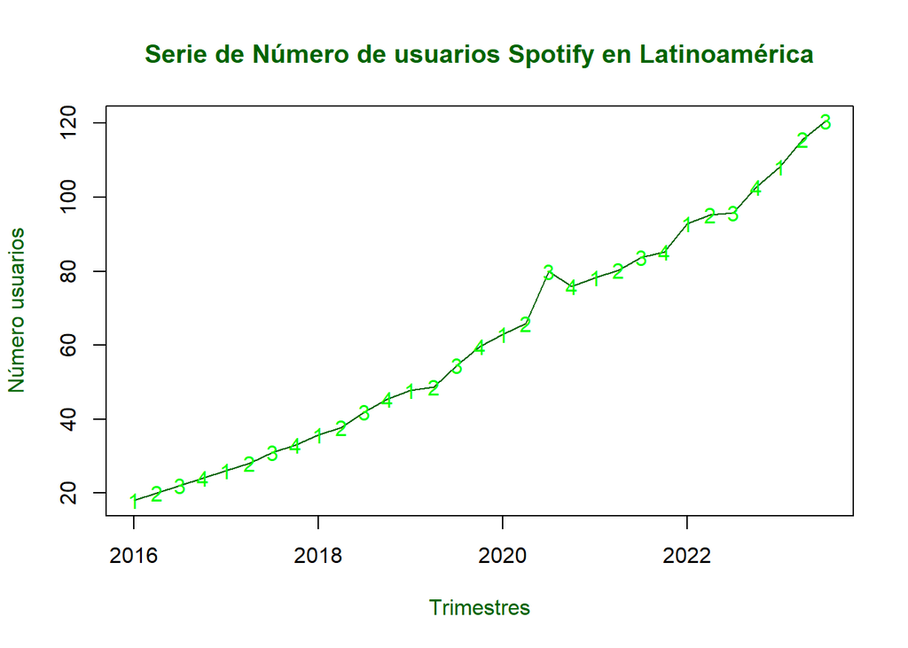

```r
plot( serie_original,col="darkgreen", ann=FALSE)
points(y=serie_original,x=time(serie_original),pch=as.vector(season(serie_original)),col="green")
title(main="Serie de Número de usuarios Spotify en Latinoamérica", col.main="darkgreen", font.main=2)
title(xlab="Trimestres", col.lab="darkgreen") #=rgb(1,0.4,1))
title(ylab="Número usuarios", col.lab="darkgreen") #=rgb(1,0.4,1))
```

- Como se aprecia en la gráfica, la serie muestra una tendencia creciente, con un descenso en el número de usuarios entre el 2020-III y 2020-IV. Este movimiento viene influenciado por los efectos económicos de las medidas de aislamiento que tomaron los gobiernos de la región debido a la pandemia por COVID-19.
- A excepción de los datos del año 2020, no se evidencia una alta volatilidad en los valores de la variable objetivo.
- Respecto a la estacionalidad, no se evidencia gráficamente un patrón claro en los múltiplos de la estación.

**Primeros correlogramas**

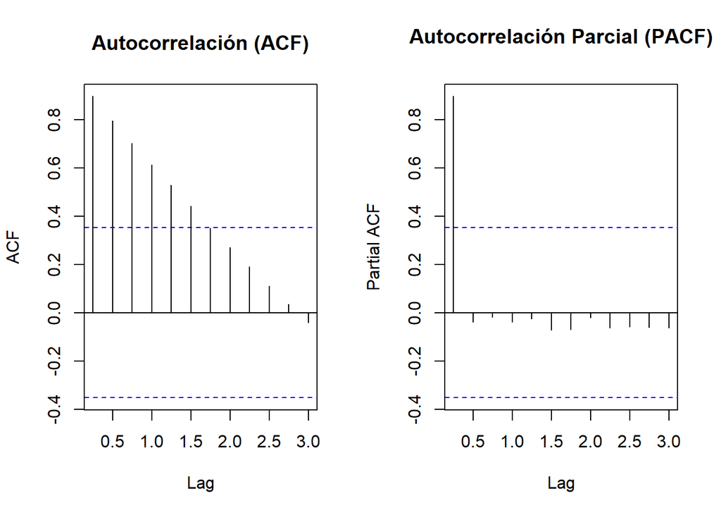

```r
par(mfrow = c(1, 2))
acf( serie_original,lag.max =12, main = "Autocorrelación (ACF)")
pacf( serie_original,lag.max =12, main = "Autocorrelación Parcial (PACF)")
```

- Desde el análisis de los correlogramas, se observa que la autocorrelación acumulada (FAC) decae de manera sostenida y después del rezago N° 6, toma valores estadísticamente iguales a cero (dentro de la banda azul), mientras que la autocorrelación parcial (PACF) sólo presenta valores significativamente diferentes de cero en el rezago 1 ($h = 1$).

# Modelo SARIMA

## Estacionalidad de la serie

Con el fin de hacer que la serie sea estacionaria en el sentido débil, se realizan a continuación una serie de pruebas respecto a las transformaciones y órdenes de diferenciación a aplicar.

Se exploran combinaciones a partir de las opciones:

- Niveles de la serie:
  - Serie con valores en la escala original.
  - Serie con valores en la escala logarítmica.
  - Serie con valores transformados a la potencia óptima, indicada por el algoritmo Box-Cox.
- Órdenes de diferenciación:
  - 1 diferencia ordinaria
  - 2 diferencias ordinarias
  - 1 diferencia ordinaria y 1 estacional

### Valores en escala original - Diferencias ordinarias y estacionales

1. Criterio de Victor Guerrero - mínima desviación estándar

```r
s00=sd(serie_original)
s10=sd(diff(serie_original,lag=1,differences=1))#(1-B) X_{t}
s101=sd(diff(serie_original,lag=1,differences=2))#(1-B)^2 X_{t}

s01=sd(diff(serie_original,lag=4,differences=1))#(1-B^4) X_{t}

dif1usuarios<-diff(serie_original,lag=1,differences=1)##(1-B) X_{t}
s11=sd(diff(dif1usuarios,lag=4,differences=1))#(1-B^4)(1-B) X_{t}
s21=sd(diff(dif1usuarios,lag=4,differences=2))#(1-B^4)^2(1-B) X_{t}
s20=sd(diff(serie_original,lag=1,differences=2))#(1-B)^2 X_{t}

cat(paste("\n\nEl valor de la desviación estándar de la alternativa s00: la serie sin diferenciar es de:\n", s00))
```

```
##
##
## El valor de la desviación estándar de la alternativa s00: la serie sin diferenciar es de:
##  31.0019158963976
```

```r
cat(paste("\n\nEl valor de la desviación estándar de la alternativa s10: la serie con 1 diferencia ordinaria es de:\n", s10))
```

```
##
##
## El valor de la desviación estándar de la alternativa s10: la serie con 1 diferencia ordinaria es de:
##  3.07427412234341
```

```r
cat(paste("\n\nEl valor de la desviación estándar de la alternativa s101: la serie con 2 diferencias ordinarias es de:\n", s101))
```

```
##
##
## El valor de la desviación estándar de la alternativa s101: la serie con 2 diferencias ordinarias es de:
##  4.91168625042969
```

```r
cat(paste("\n\nEl valor de la desviación estándar de la alternativa s01: la serie con 1 diferencia estacional es de:\n", s01))
```

```
##
##
## El valor de la desviación estándar de la alternativa s01: la serie con 1 diferencia estacional es de:
##  4.91105137837364
```

```r
cat(paste("\n\nEl valor de la desviación estándar de la alternativa s11: la serie con 1 diferencia estacional y 1 diferencia ordinaria es de:\n", s11))
```

```
##
##
## El valor de la desviación estándar de la alternativa s11: la serie con 1 diferencia estacional y 1 diferencia ordinaria es de:
##  4.09997973728576
```

```r
cat(paste("\n\nEl valor de la desviación estándar de la alternativa s21: la serie con 2 diferencias estacionales y 1 diferencia ordinaria es de:\n", s21))
```

```
##
##
## El valor de la desviación estándar de la alternativa s21: la serie con 2 diferencias estacionales y 1 diferencia ordinaria es de:
##  6.83661608403745
```

```r
cat(paste("\n\nEl valor de la desviación estándar de la alternativa s20: la serie con 2 diferencias estacionales y ninguna diferencia ordinaria es de:\n", s20))
```

```
##
##
## El valor de la desviación estándar de la alternativa s20: la serie con 2 diferencias estacionales y ninguna diferencia ordinaria es de:
##  4.91168625042969
```

- De acuerdo con el criterio de mínima desviación estándar (Víctor Guerrero), la mejor alternativa de diferenciación para la serie de usuarios de Spotify en Latinoamérica es aquella en que a la serie se le aplica sólo 1 diferencia ordinaria ( $SD = 3.07$ ), seguido por la alternativa de 1 diferencia estacional y 1 diferencia ordinaria ( $SD = 4.09$ ).
2. Criterio de decaimiento de la FAC

```r
cat(print("\n\nSerie con 1 diferencia ordinaria\n\n"))
```

```
## [1] "\n\nSerie con 1 diferencia ordinaria\n\n"
##
##
## Serie con 1 diferencia ordinaria
```

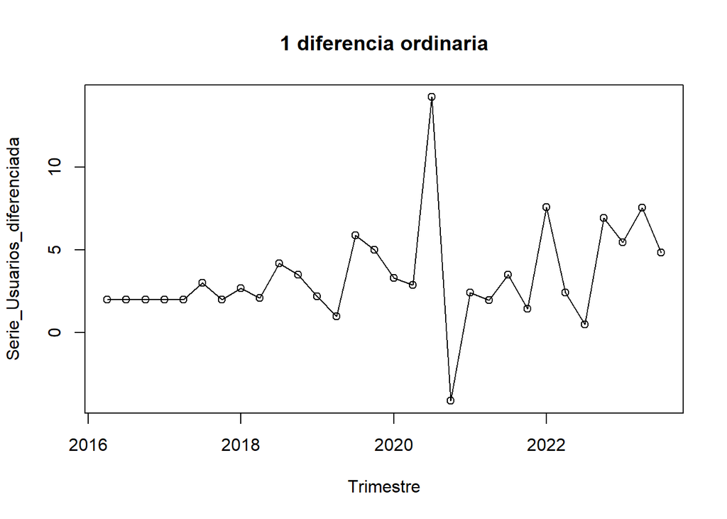

```r
# Serie con 1 diferencia ordinaria
dusuarios1<-diff(serie_original,lag=1,differences=1)

#plot
plot(dusuarios1,ylab='Serie_Usuarios_diferenciada',xlab='Trimestre',type='o', main="1 diferencia ordinaria")
```

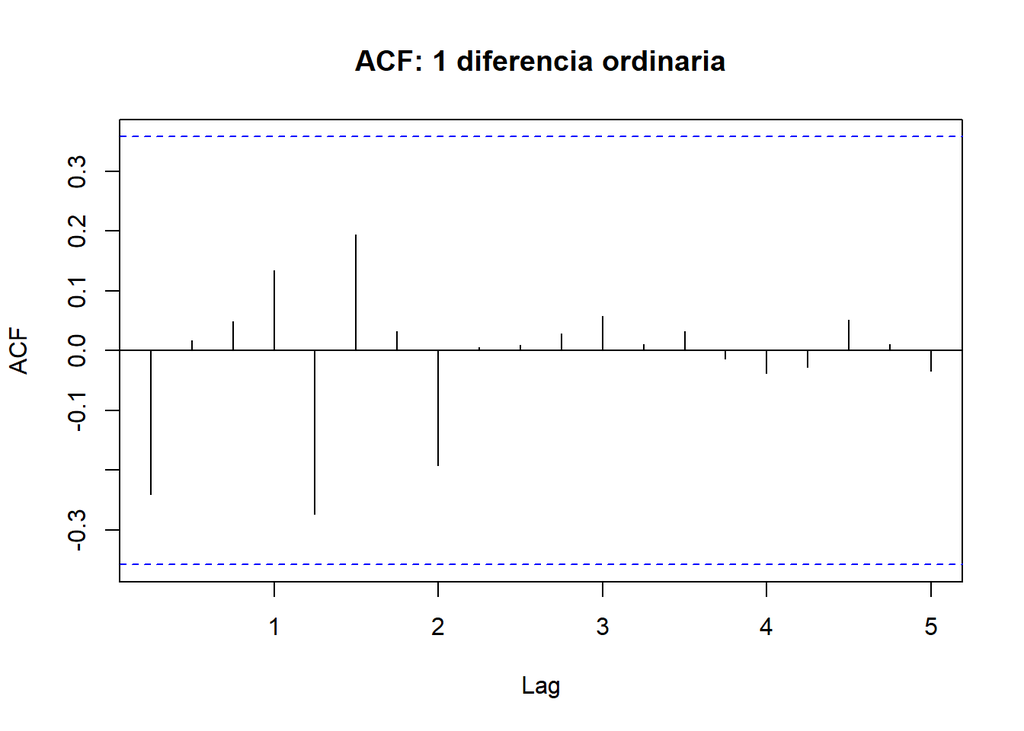

```r
#ACF para visualizar decaimiento de la estructura de autocorrelación
acf(dusuarios1, lag.max=20, main="ACF: 1 diferencia ordinaria")
```

```r
cat(print("\n\nSerie con 2 diferencias ordinarias\n\n"))
```

```
## [1] "\n\nSerie con 2 diferencias ordinarias\n\n"
##
##
## Serie con 2 diferencias ordinarias
```

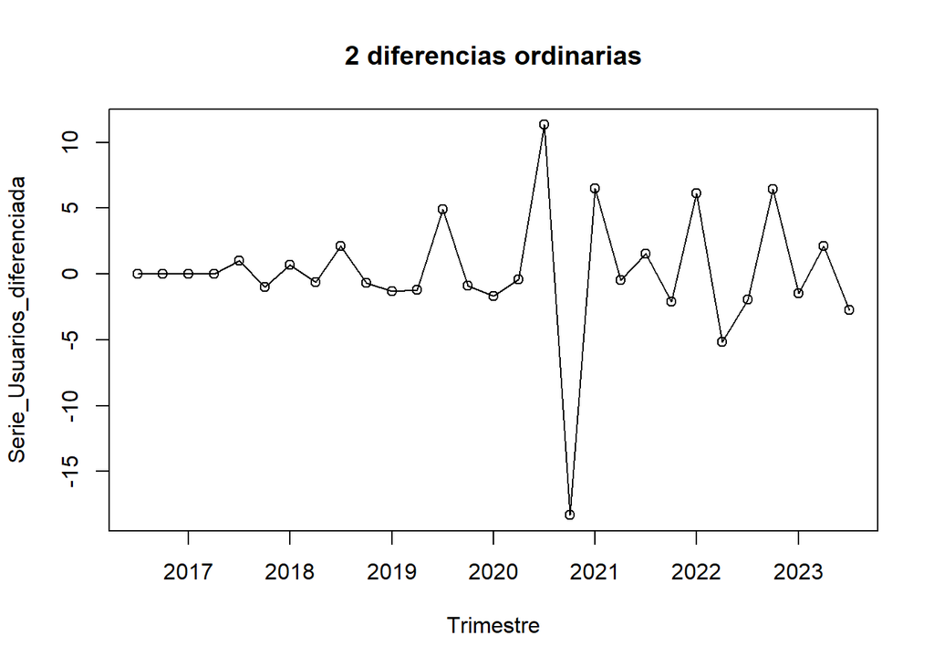

```r
# Serie con 1 diferencia ordinaria
dusuarios2<-diff(serie_original,lag=1,differences=2)

#plot
plot(dusuarios2,ylab='Serie_Usuarios_diferenciada',xlab='Trimestre',type='o', main="2 diferencias ordinarias")
```

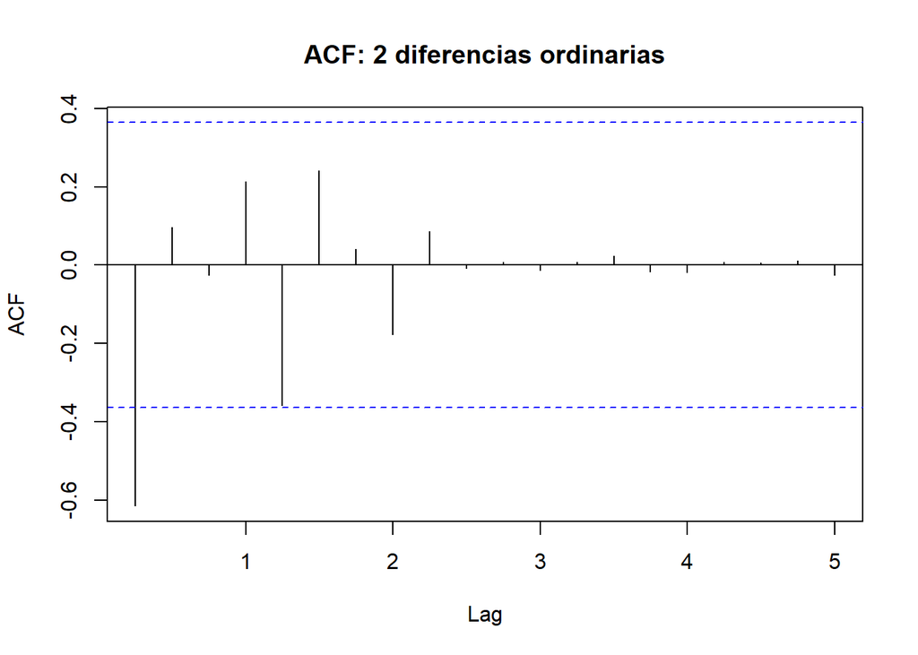

```r
#ACF para visualizar decaimiento de la estructura de autocorrelación
acf(dusuarios2, lag.max=20, main="ACF: 2 diferencias ordinarias")
```

```r
cat(print("\n\nSerie con 1 diferencia ordinaria y 1 estacional \n\n"))
```

```
## [1] "\n\nSerie con 1 diferencia ordinaria y 1 estacional \n\n"
##
##
## Serie con 1 diferencia ordinaria y 1 estacional
```

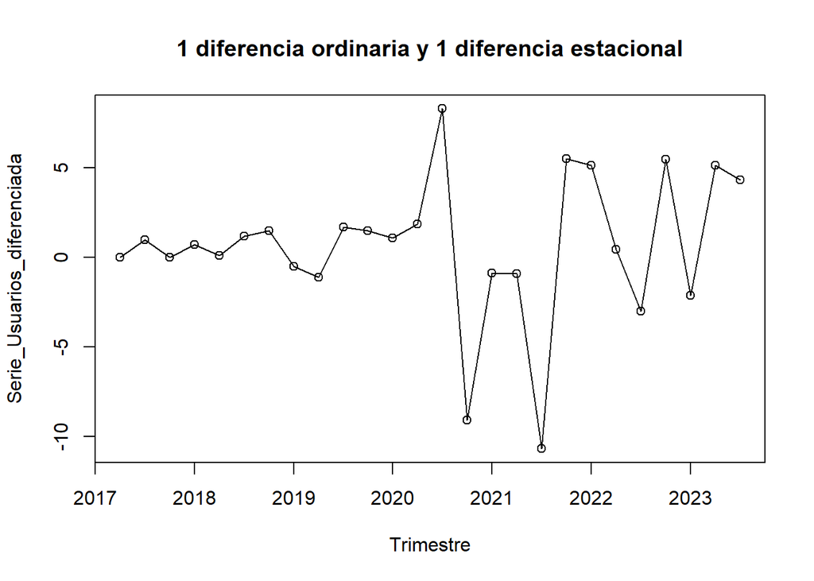

```r
# Serie con 1 diferencia ordinaria
dusuarios1_1<- diff(dif1usuarios,lag=4,differences=1)

#plot
plot(dusuarios1_1,ylab='Serie_Usuarios_diferenciada',xlab='Trimestre',type='o', main="1 diferencia ordinaria y 1 diferencia estacional")
```

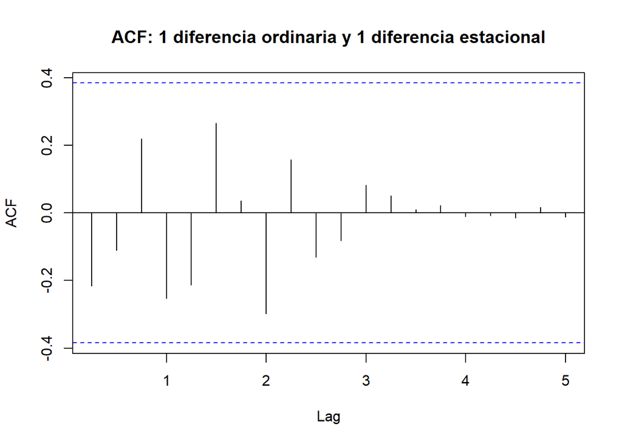

```r
#ACF para visualizar decaimiento de la estructura de autocorrelación
acf(dusuarios1_1, lag.max=20, main="ACF: 1 diferencia ordinaria y 1 diferencia estacional")
```

- De acuerdo con el criterio gráfico, únicamente la aplicación de 2 diferencias ordinarias muestra una autocorrelación acumulada significativa, en el rezago 1 ($h = 1$).
- De esta situación se interpreta que la serie es susceptible de tener subdiferenciación, por lo que la serie no podría tratarse como serie estacionaria si no se aplican 2 diferencias ordinarias.
3. Pruebas estadísticas de raíz unitaria para diferencias ordinarias (ADF y PP)

```r
library(tseries)
#Pruebas aplicadas a la serie original
cat(print("\n\nPruebas aplicadas a la serie original\n"))
```

```
## [1] "\n\nPruebas aplicadas a la serie original\n"
##
##
## Pruebas aplicadas a la serie original
```

```r
adf.test(serie_original)
```

```
##
##  Augmented Dickey-Fuller Test
##
## data:  serie_original
## Dickey-Fuller = -1.4256, Lag order = 3, p-value = 0.7939
## alternative hypothesis: stationary
```

```r
pp.test(serie_original)
```

```
##
##  Phillips-Perron Unit Root Test
##
## data:  serie_original
## Dickey-Fuller Z(alpha) = -7.5785, Truncation lag parameter = 2, p-value
## = 0.6431
## alternative hypothesis: stationary
```

```r
#Pruebas aplicadas a la serie con 1 diferencia ordinaria
cat(print("\n\nPruebas aplicadas a la serie con 1 diferencia ordinaria\n"))
```

```
## [1] "\n\nPruebas aplicadas a la serie con 1 diferencia ordinaria\n"
##
##
## Pruebas aplicadas a la serie con 1 diferencia ordinaria
```

```r
adf.test(dusuarios1)
```

```
##
##  Augmented Dickey-Fuller Test
##
## data:  dusuarios1
## Dickey-Fuller = -2.1824, Lag order = 3, p-value = 0.5026
## alternative hypothesis: stationary
```

```r
pp.test(dusuarios1)
```

```
##
##  Phillips-Perron Unit Root Test
##
## data:  dusuarios1
## Dickey-Fuller Z(alpha) = -36.455, Truncation lag parameter = 2, p-value
## = 0.01
## alternative hypothesis: stationary
```

```r
#Pruebas aplicadas a la serie con 2 diferencias ordinarias
cat(print("\n\nPruebas aplicadas a la serie con 2 diferencias ordinarias\n"))
```

```
## [1] "\n\nPruebas aplicadas a la serie con 2 diferencias ordinarias\n"
##
##
## Pruebas aplicadas a la serie con 2 diferencias ordinarias
```

```r
adf.test(dusuarios2)
```

```
##
##  Augmented Dickey-Fuller Test
##
## data:  dusuarios2
## Dickey-Fuller = -3.4231, Lag order = 3, p-value = 0.07322
## alternative hypothesis: stationary
```

```r
pp.test(dusuarios2)
```

```
##
##  Phillips-Perron Unit Root Test
##
## data:  dusuarios2
## Dickey-Fuller Z(alpha) = -39.607, Truncation lag parameter = 2, p-value
## = 0.01
## alternative hypothesis: stationary
```

```r
#Pruebas aplicadas a la serie con 1 diferencia ordinaria
cat(print("\n\nPruebas aplicadas a la serie con 1 diferencia ordinaria y 1 estacional\n"))
```

```
## [1] "\n\nPruebas aplicadas a la serie con 1 diferencia ordinaria y 1 estacional\n"
##
##
## Pruebas aplicadas a la serie con 1 diferencia ordinaria y 1 estacional
```

```r
adf.test(diff(dif1usuarios,lag=4,differences=1))
```

```
##
##  Augmented Dickey-Fuller Test
##
## data:  diff(dif1usuarios, lag = 4, differences = 1)
## Dickey-Fuller = -2.3014, Lag order = 2, p-value = 0.4575
## alternative hypothesis: stationary
```

```r
pp.test(diff(dif1usuarios,lag=4,differences=1))
```

```
##
##  Phillips-Perron Unit Root Test
##
## data:  diff(dif1usuarios, lag = 4, differences = 1)
## Dickey-Fuller Z(alpha) = -28.988, Truncation lag parameter = 2, p-value
## = 0.01
## alternative hypothesis: stationary
```

**Resultados:**

1. Pruebas aplicadas a la serie sin diferenciar:

- ❌ADF: El p-valor (0.79) no rechaza la hipótesis nula, por lo tanto la serie no es estacionaria.

- ❌Philiips-Perron: El p-valor (0.64) no rechaza la hipótesis nula, por lo tanto la serie no es estacionaria.

2. Pruebas aplicadas a la serie con 1 diferencia ordinaria:

- ❌ADF: El p-valor (0.50) no rechaza la hipótesis nula, por lo tanto la serie no es estacionaria.

- ✅Philiips-Perron: El p-valor (<0.01) rechaza la hipótesis nula, por lo tanto la serie es estacionaria.

3. Pruebas aplicadas a la serie con 2 diferencias ordinarias:

- ❌ADF: El p-valor (0.07) no rechaza la hipótesis nula, por lo tanto la serie no es estacionaria.

- ✅Philiips-Perron: El p-valor (<0.01) rechaza la hipótesis nula, por lo tanto la serie es estacionaria.

4. Pruebas aplicadas a la serie con 1 diferencia ordinaria y 1 estacional:

- ❌ADF: El p-valor (0.45) no rechaza la hipótesis nula, por lo tanto la serie no es estacionaria.

- ✅Philiips-Perron: El p-valor (<0.01) rechaza la hipótesis nula, por lo tanto la serie es estacionaria.

### Valores en logaritmos - Diferencias ordinarias y estacionales

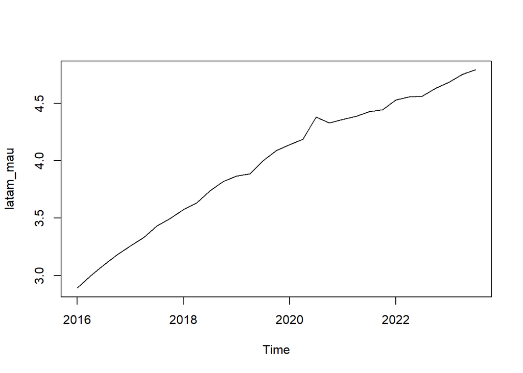

```r
serie_log <- log(serie_original)
plot(serie_log)
```

1. Criterio de Victor Guerrero - mínima desviación estándar

```r
sl00=sd(serie_log)
sl10=sd(diff(serie_log,lag=1,differences=1))#(1-B) X_{t}
sl101=sd(diff(serie_log,lag=1,differences=2))#(1-B)^2 X_{t}
sl01=sd(diff(serie_log,lag=4,differences=1))#(1-B^4) X_{t}

dif1logusuarios<-diff(serie_log,lag=1,differences=1)##(1-B) X_{t}
sl11=sd(diff(dif1logusuarios,lag=4,differences=1))#(1-B^4)(1-B) X_{t}
sl21=sd(diff(dif1logusuarios,lag=4,differences=2))#(1-B^4)^2(1-B) X_{t}
sl20=sd(diff(serie_log,lag=1,differences=2))#(1-B)^2 X_{t}

cat(paste("\n\nEl valor de la desviación estándar de la alternativa s00: la serie sin diferenciar es de:\n", sl00))
```

```
##
##
## El valor de la desviación estándar de la alternativa s00: la serie sin diferenciar es de:
##  0.568455146775194
```

```r
cat(paste("\n\nEl valor de la desviación estándar de la alternativa s10: la serie con 1 diferencia ordinaria es de:\n", sl10))
```

```
##
##
## El valor de la desviación estándar de la alternativa s10: la serie con 1 diferencia ordinaria es de:
##  0.0436385515342665
```

```r
cat(paste("\n\nEl valor de la desviación estándar de la alternativa s101: la serie con 2 diferencias ordinarias es de:\n", sl101))
```

```
##
##
## El valor de la desviación estándar de la alternativa s101: la serie con 2 diferencias ordinarias es de:
##  0.0668617125543412
```

```r
cat(paste("\n\nEl valor de la desviación estándar de la alternativa s01: la serie con 1 diferencia estacional es de:\n", sl01))
```

```
##
##
## El valor de la desviación estándar de la alternativa s01: la serie con 1 diferencia estacional es de:
##  0.0828647830760421
```

```r
cat(paste("\n\nEl valor de la desviación estándar de la alternativa s11: la serie con 1 diferencia estacional y 1 diferencia ordinaria es de:\n", sl11))
```

```
##
##
## El valor de la desviación estándar de la alternativa s11: la serie con 1 diferencia estacional y 1 diferencia ordinaria es de:
##  0.0533646928610388
```

```r
cat(paste("\n\nEl valor de la desviación estándar de la alternativa s21: la serie con 2 diferencias estacionales y 1 diferencia ordinaria es de:\n", sl21))
```

```
##
##
## El valor de la desviación estándar de la alternativa s21: la serie con 2 diferencias estacionales y 1 diferencia ordinaria es de:
##  0.0901529535683932
```

```r
cat(paste("\n\nEl valor de la desviación estándar de la alternativa s20: la serie con 2 diferencias estacionales y ninguna diferencia ordinaria es de:\n", sl20))
```

```
##
##
## El valor de la desviación estándar de la alternativa s20: la serie con 2 diferencias estacionales y ninguna diferencia ordinaria es de:
##  0.0668617125543412
```

- De acuerdo con el criterio de mínima desviación estándar (Víctor Guerrero), la mejor alternativa de diferenciación para la serie de usuarios de Spotify en Latinoamérica es aquella en que a la serie se le aplica sólo 1 diferencia ordinaria ( $SD = 0.043$ ), seguido por la alternativa de 1 diferencia estacional y 1 diferencia ordinaria ( $SD = 0.053$ ).
2. Criterio de decaimiento de la FAC

```r
cat(print("\n\nSerie con 1 diferencia ordinaria\n\n"))
```

```
## [1] "\n\nSerie con 1 diferencia ordinaria\n\n"
##
##
## Serie con 1 diferencia ordinaria
```

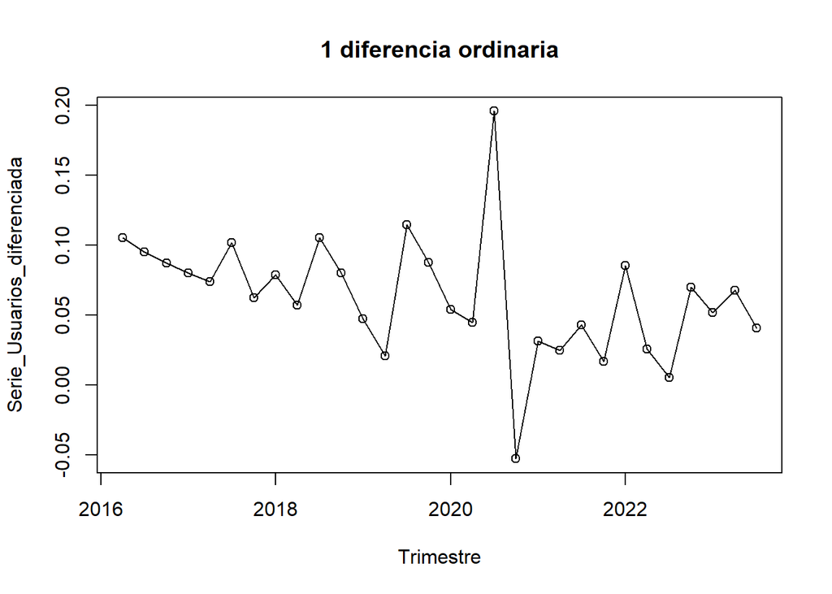

```r
# Serie con 1 diferencia ordinaria
dlogusuarios1<-diff(serie_log,lag=1,differences=1)
#plot
plot(dlogusuarios1,ylab='Serie_Usuarios_diferenciada',xlab='Trimestre',type='o', main="1 diferencia ordinaria")
```

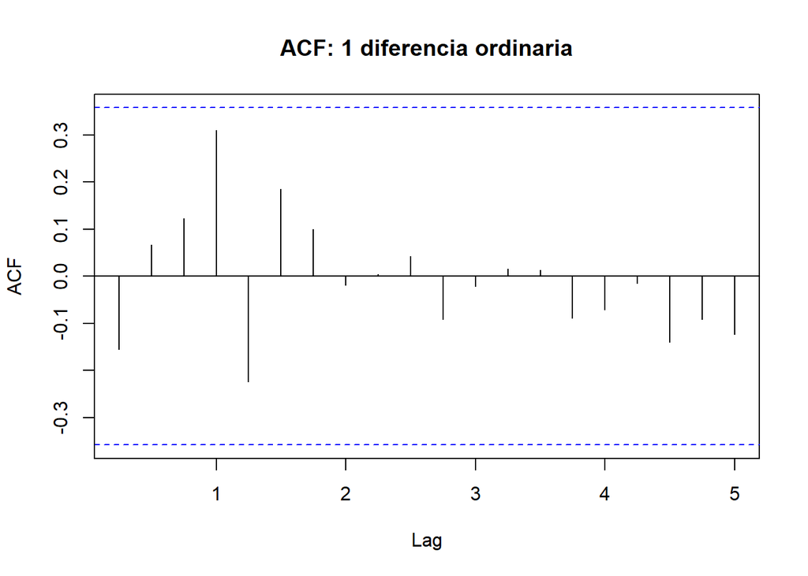

```r
#ACF para visualizar decaimiento de la estructura de autocorrelación
acf(dlogusuarios1, lag.max=20, main="ACF: 1 diferencia ordinaria")
```

```r
cat(print("\n\nSerie con 2 diferencias ordinarias\n\n"))
```

```
## [1] "\n\nSerie con 2 diferencias ordinarias\n\n"
##
##
## Serie con 2 diferencias ordinarias
```

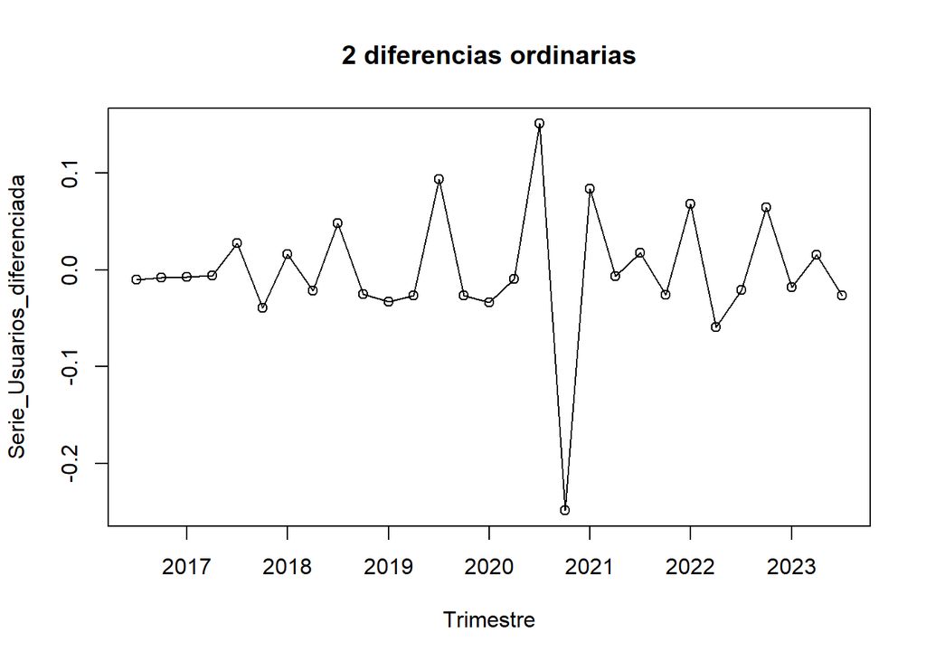

```r
# Serie con 1 diferencia ordinaria
dlogusuarios2<-diff(serie_log,lag=1,differences=2)
#plot
plot(dlogusuarios2,ylab='Serie_Usuarios_diferenciada',xlab='Trimestre',type='o', main="2 diferencias ordinarias")
```

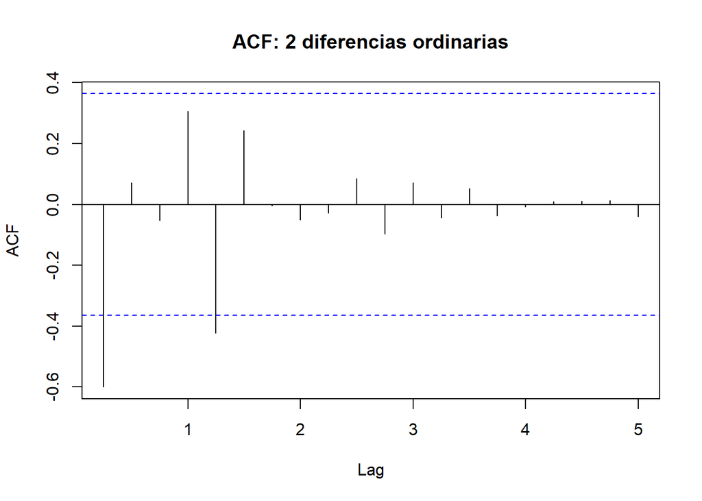

```r
#ACF para visualizar decaimiento de la estructura de autocorrelación
acf(dlogusuarios2, lag.max=20, main="ACF: 2 diferencias ordinarias")
```

- De acuerdo con el criterio gráfico, únicamente la aplicación de 2 diferencias ordinarias muestra una autocorrelación acumulada significativa, en los rezagos 1 y 5 (*h = 1, 5* ).
- De esta situación se interpreta que la serie es susceptible de tener subdiferenciación, por lo que la serie no podría tratarse como serie estacionaria si no se aplican 2 diferencias ordinarias.
3. Pruebas estadísticas de raíz unitaria para diferencias ordinarias (ADF y PP)

```r
#Pruebas aplicadas a la serie transformada con logaritmo natural
cat(print("\n\nPruebas aplicadas a la serie transformada con logaritmo natural\n"))
```

```
## [1] "\n\nPruebas aplicadas a la serie transformada con logaritmo natural\n"
##
##
## Pruebas aplicadas a la serie transformada con logaritmo natural
```

```r
adf.test(serie_log)
```

```
##
##  Augmented Dickey-Fuller Test
##
## data:  serie_log
## Dickey-Fuller = -1.0894, Lag order = 3, p-value = 0.909
## alternative hypothesis: stationary
```

```r
pp.test(serie_log)
```

```
##
##  Phillips-Perron Unit Root Test
##
## data:  serie_log
## Dickey-Fuller Z(alpha) = -3.2774, Truncation lag parameter = 2, p-value
## = 0.9172
## alternative hypothesis: stationary
```

```r
#Pruebas aplicadas a la serie con 1 diferencia ordinaria
cat(print("\n\nPruebas aplicadas a la serie con 1 diferencia ordinaria\n"))
```

```
## [1] "\n\nPruebas aplicadas a la serie con 1 diferencia ordinaria\n"
##
##
## Pruebas aplicadas a la serie con 1 diferencia ordinaria
```

```r
adf.test(dlogusuarios1)
```

```
##
##  Augmented Dickey-Fuller Test
##
## data:  dlogusuarios1
## Dickey-Fuller = -2.1228, Lag order = 3, p-value = 0.5255
## alternative hypothesis: stationary
```

```r
pp.test(dlogusuarios1)
```

```
##
##  Phillips-Perron Unit Root Test
##
## data:  dlogusuarios1
## Dickey-Fuller Z(alpha) = -35.548, Truncation lag parameter = 2, p-value
## = 0.01
## alternative hypothesis: stationary
```

```r
#Pruebas aplicadas a la serie con 2 diferencias ordinarias
cat(print("\n\nPruebas aplicadas a la serie con 2 diferencias ordinarias\n"))
```

```
## [1] "\n\nPruebas aplicadas a la serie con 2 diferencias ordinarias\n"
##
##
## Pruebas aplicadas a la serie con 2 diferencias ordinarias
```

```r
adf.test(dlogusuarios2)
```

```
##
##  Augmented Dickey-Fuller Test
##
## data:  dlogusuarios2
## Dickey-Fuller = -3.5507, Lag order = 3, p-value = 0.05526
## alternative hypothesis: stationary
```

```r
pp.test(dlogusuarios2)
```

```
##
##  Phillips-Perron Unit Root Test
##
## data:  dlogusuarios2
## Dickey-Fuller Z(alpha) = -38.833, Truncation lag parameter = 2, p-value
## = 0.01
## alternative hypothesis: stationary
```

```r
#Pruebas aplicadas a la serie con 1 diferencia ordinaria
cat(print("\n\nPruebas aplicadas a la serie con 1 diferencia ordinaria y 1 estacional\n"))
```

```
## [1] "\n\nPruebas aplicadas a la serie con 1 diferencia ordinaria y 1 estacional\n"
##
##
## Pruebas aplicadas a la serie con 1 diferencia ordinaria y 1 estacional
```

```r
adf.test(diff(dif1logusuarios,lag=4,differences=1))
```

```
##
##  Augmented Dickey-Fuller Test
##
## data:  diff(dif1logusuarios, lag = 4, differences = 1)
## Dickey-Fuller = -2.3864, Lag order = 2, p-value = 0.4252
## alternative hypothesis: stationary
```

```r
pp.test(diff(dif1logusuarios,lag=4,differences=1))
```

```
##
##  Phillips-Perron Unit Root Test
##
## data:  diff(dif1logusuarios, lag = 4, differences = 1)
## Dickey-Fuller Z(alpha) = -28.513, Truncation lag parameter = 2, p-value
## = 0.01
## alternative hypothesis: stationary
```

**Resultados:**

1. Pruebas aplicadas a la serie transformada con logaritmo natural sin diferenciación:

- ❌ADF: El p-valor (0.91) no rechaza la hipótesis nula, por lo tanto la serie no es estacionaria.

- ❌Philiips-Perron: El p-valor (0.91) no rechaza la hipótesis nula, por lo tanto la serie no es estacionaria.

2. Pruebas aplicadas a la serie con 1 diferencia ordinaria:

- ❌ADF: El p-valor (0.52) no rechaza la hipótesis nula, por lo tanto la serie no es estacionaria.

- ✅Philiips-Perron: El p-valor (<0.01) rechaza la hipótesis nula, por lo tanto la serie es estacionaria.

3. Pruebas aplicadas a la serie con 2 diferencias ordinarias:

- ❌ADF: El p-valor (0.055) no rechaza la hipótesis nula, por lo tanto la serie no es estacionaria.

- ✅Philiips-Perron: El p-valor (<0.01) rechaza la hipótesis nula, por lo tanto la serie es estacionaria.

4. Pruebas aplicadas a la serie con 1 diferencia ordinaria y 1 estacional:

- ❌ADF: El p-valor (0.42) no rechaza la hipótesis nula, por lo tanto la serie no es estacionaria.

- ✅Philiips-Perron: El p-valor (<0.01) rechaza la hipótesis nula, por lo tanto la serie es estacionaria.

### Valores a la potencia (algoritmo Box-Cox) - Diferencias ordinarias y estacionales

```r
library(forecast)
lambda_optimo <- BoxCox.lambda(serie_original) # Encuentra el mejor lambda
print(cat("El valor óptimo del lambda es de", lambda_optimo))
```

```
## El valor óptimo del lambda es de 0.3306029NULL
```

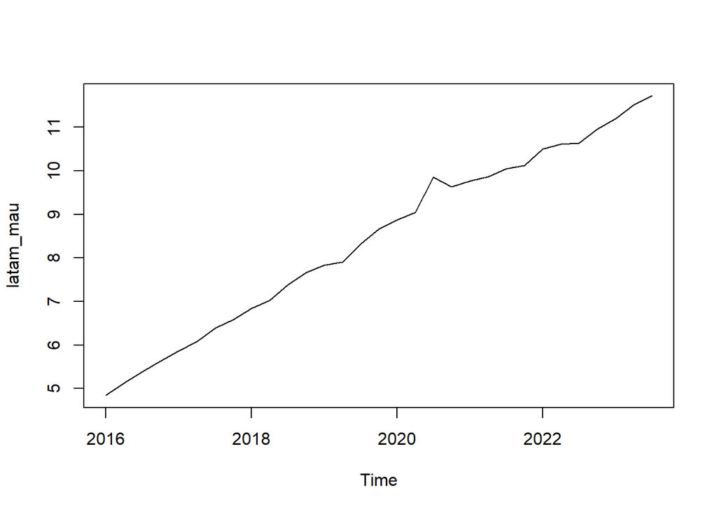

```r
serie_boxcox <- BoxCox(serie_original, lambda = lambda_optimo)
plot(serie_boxcox)
```

- El valor óptimo de lambda encontrado por el algoritmo Box-Cox fue de 0.33.

1. Criterio de Victor Guerrero - mínima desviación estándar

```r
sbc00=sd(serie_boxcox)
sbc10=sd(diff(serie_boxcox,lag=1,differences=1))#(1-B) X_{t}
sbc101=sd(diff(serie_boxcox,lag=1,differences=2))#(1-B)^2 X_{t}
sbc01=sd(diff(serie_boxcox,lag=4,differences=1))#(1-B^4) X_{t}

dif1boxcoxusuarios<-diff(serie_boxcox,lag=1,differences=1)##(1-B) X_{t}
sbc11=sd(diff(dif1boxcoxusuarios,lag=4,differences=1))#(1-B^4)(1-B) X_{t}
sbc21=sd(diff(dif1boxcoxusuarios,lag=4,differences=2))#(1-B^4)^2(1-B) X_{t}
sbc20=sd(diff(serie_boxcox,lag=1,differences=2))#(1-B)^2 X_{t}

cat(paste("\n\nEl valor de la desviación estándar de la alternativa s00: la serie sin diferenciar es de:\n", sbc00))
```

```
##
##
## El valor de la desviación estándar de la alternativa s00: la serie sin diferenciar es de:
##  2.07808368217315
```

```r
cat(paste("\n\nEl valor de la desviación estándar de la alternativa s10: la serie con 1 diferencia ordinaria es de:\n", sbc10))
```

```
##
##
## El valor de la desviación estándar de la alternativa s10: la serie con 1 diferencia ordinaria es de:
##  0.165403454155977
```

```r
cat(paste("\n\nEl valor de la desviación estándar de la alternativa s101: la serie con 2 diferencias ordinarias es de:\n", sbc101))
```

```
##
##
## El valor de la desviación estándar de la alternativa s101: la serie con 2 diferencias ordinarias es de:
##  0.274538014914582
```

```r
cat(paste("\n\nEl valor de la desviación estándar de la alternativa s01: la serie con 1 diferencia estacional es de:\n", sbc01))
```

```
##
##
## El valor de la desviación estándar de la alternativa s01: la serie con 1 diferencia estacional es de:
##  0.236948873493733
```

```r
cat(paste("\n\nEl valor de la desviación estándar de la alternativa s11: la serie con 1 diferencia estacional y 1 diferencia ordinaria es de:\n", sbc11))
```

```
##
##
## El valor de la desviación estándar de la alternativa s11: la serie con 1 diferencia estacional y 1 diferencia ordinaria es de:
##  0.222563927082975
```

```r
cat(paste("\n\nEl valor de la desviación estándar de la alternativa s21: la serie con 2 diferencias estacionales y 1 diferencia ordinaria es de:\n", sbc21))
```

```
##
##
## El valor de la desviación estándar de la alternativa s21: la serie con 2 diferencias estacionales y 1 diferencia ordinaria es de:
##  0.375990813674117
```

```r
cat(paste("\n\nEl valor de la desviación estándar de la alternativa s20: la serie con 2 diferencias estacionales y ninguna diferencia ordinaria es de:\n", sbc20))
```

```
##
##
## El valor de la desviación estándar de la alternativa s20: la serie con 2 diferencias estacionales y ninguna diferencia ordinaria es de:
##  0.274538014914582
```

- De acuerdo con el criterio de mínima desviación estándar (Víctor Guerrero), la mejor alternativa de diferenciación para la serie de usuarios de Spotify en Latinoamérica es aquella en que a la serie se le aplica sólo 1 diferencia ordinaria ( *SD = 0.16* ), seguido por la alternativa de 1 diferencia estacional y 1 diferencia ordinaria ( *SD = 0.22* ).

2. Criterio de decaimiento de la FAC

```r
cat(print("\n\nSerie con 1 diferencia ordinaria\n\n"))
```

```
## [1] "\n\nSerie con 1 diferencia ordinaria\n\n"
##
##
## Serie con 1 diferencia ordinaria
```

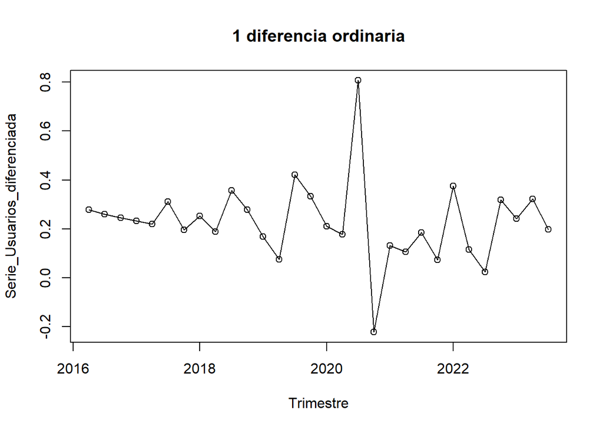

```r
# Serie con 1 diferencia ordinaria
dboxcoxusuarios1<-diff(serie_boxcox,lag=1,differences=1)
#plot
plot(dboxcoxusuarios1,ylab='Serie_Usuarios_diferenciada',xlab='Trimestre',type='o', main="1 diferencia ordinaria")
```

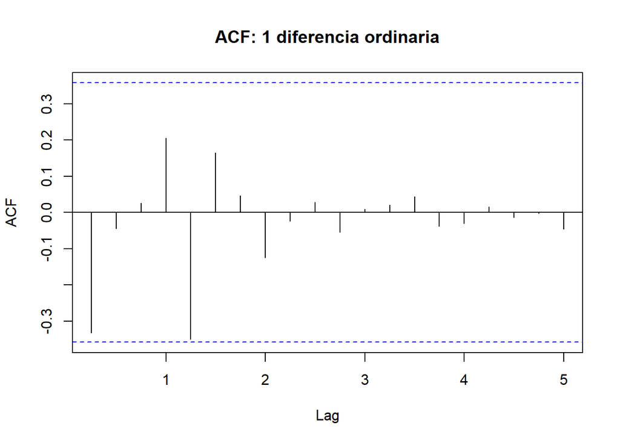

```r
#ACF para visualizar decaimiento de la estructura de autocorrelación
acf(dboxcoxusuarios1, lag.max=20, main="ACF: 1 diferencia ordinaria")
```

```r
cat(print("\n\nSerie con 2 diferencias ordinarias\n\n"))
```

```
## [1] "\n\nSerie con 2 diferencias ordinarias\n\n"
##
##
## Serie con 2 diferencias ordinarias
```

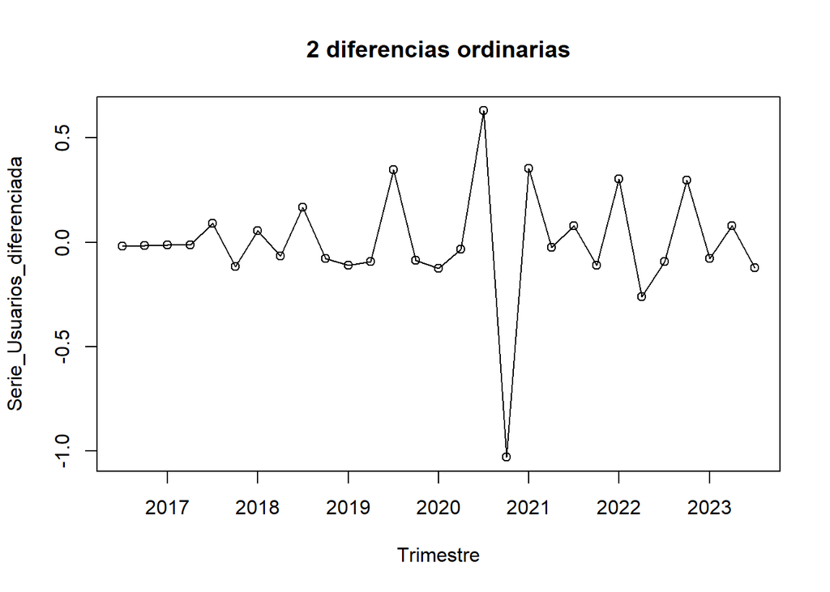

```r
# Serie con 1 diferencia ordinaria
dboxcoxusuarios2<-diff(serie_boxcox,lag=1,differences=2)
#plot
plot(dboxcoxusuarios2,ylab='Serie_Usuarios_diferenciada',xlab='Trimestre',type='o', main="2 diferencias ordinarias")
```

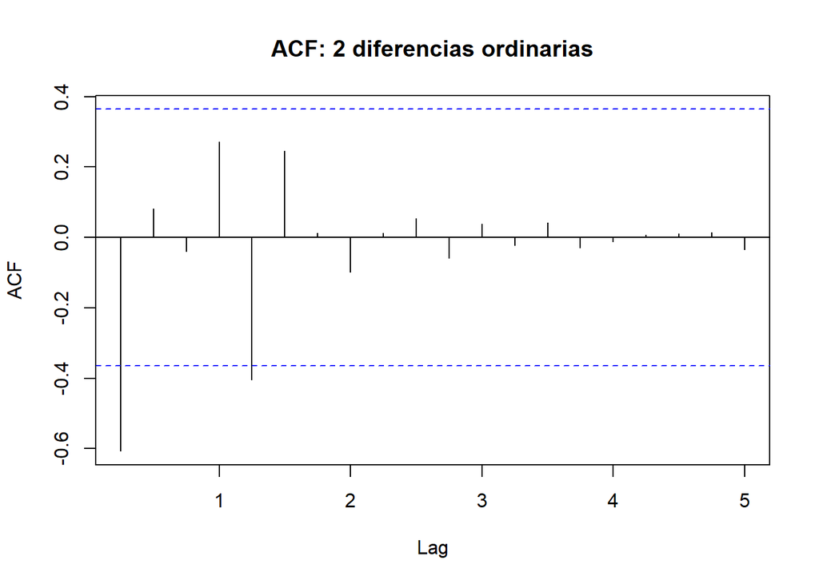

```r
#ACF para visualizar decaimiento de la estructura de autocorrelación
acf(dboxcoxusuarios2, lag.max=20, main="ACF: 2 diferencias ordinarias")
```

- De acuerdo con el criterio gráfico, únicamente la aplicación de 2 diferencias ordinarias muestra una autocorrelación acumulada significativa, en los rezagos 1 y 5 ($h = 1, 5$).
- De esta situación se interpreta que la serie es susceptible de tener subdiferenciación, por lo que la serie no podría tratarse como serie estacionaria si no se aplican 2 diferencias ordinarias.

3. Pruebas estadísticas de raíz unitaria para diferencias ordinarias (ADF y PP)

```r
#Pruebas aplicadas a la serie transformada con boxcox natural
cat(print("\n\nPruebas aplicadas a la serie transformada con boxcox\n"))
```

```
## [1] "\n\nPruebas aplicadas a la serie transformada con boxcox\n"
##
##
## Pruebas aplicadas a la serie transformada con boxcox
```

```r
adf.test(serie_boxcox)
```

```
##
##  Augmented Dickey-Fuller Test
##
## data:  serie_boxcox
## Dickey-Fuller = -1.3537, Lag order = 3, p-value = 0.8216
## alternative hypothesis: stationary
```

```r
pp.test(serie_boxcox)
```

```
##
##  Phillips-Perron Unit Root Test
##
## data:  serie_boxcox
## Dickey-Fuller Z(alpha) = -9.6221, Truncation lag parameter = 2, p-value
## = 0.5087
## alternative hypothesis: stationary
```

```r
#Pruebas aplicadas a la serie con 1 diferencia ordinaria
cat(print("\n\nPruebas aplicadas a la serie con 1 diferencia ordinaria\n"))
```

```
## [1] "\n\nPruebas aplicadas a la serie con 1 diferencia ordinaria\n"
##
##
## Pruebas aplicadas a la serie con 1 diferencia ordinaria
```

```r
adf.test(dboxcoxusuarios1)
```

```
##
##  Augmented Dickey-Fuller Test
##
## data:  dboxcoxusuarios1
## Dickey-Fuller = -2.1749, Lag order = 3, p-value = 0.5055
## alternative hypothesis: stationary
```

```r
pp.test(dboxcoxusuarios1)
```

```
##
##  Phillips-Perron Unit Root Test
##
## data:  dboxcoxusuarios1
## Dickey-Fuller Z(alpha) = -36.068, Truncation lag parameter = 2, p-value
## = 0.01
## alternative hypothesis: stationary
```

```r
#Pruebas aplicadas a la serie con 2 diferencias ordinarias
cat(print("\n\nPruebas aplicadas a la serie con 2 diferencias ordinarias\n"))
```

```
## [1] "\n\nPruebas aplicadas a la serie con 2 diferencias ordinarias\n"
##
##
## Pruebas aplicadas a la serie con 2 diferencias ordinarias
```

```r
adf.test(dboxcoxusuarios2)
```

```
##
##  Augmented Dickey-Fuller Test
##
## data:  dboxcoxusuarios2
## Dickey-Fuller = -3.4701, Lag order = 3, p-value = 0.0666
## alternative hypothesis: stationary
```

```r
pp.test(dboxcoxusuarios2)
```

```
##
##  Phillips-Perron Unit Root Test
##
## data:  dboxcoxusuarios2
## Dickey-Fuller Z(alpha) = -39.131, Truncation lag parameter = 2, p-value
## = 0.01
## alternative hypothesis: stationary
```

```r
#Pruebas aplicadas a la serie con 1 diferencia ordinaria
cat(print("\n\nPruebas aplicadas a la serie con 1 diferencia ordinaria y 1 estacional\n"))
```

```
## [1] "\n\nPruebas aplicadas a la serie con 1 diferencia ordinaria y 1 estacional\n"
##
##
## Pruebas aplicadas a la serie con 1 diferencia ordinaria y 1 estacional
```

```r
adf.test(diff(dif1boxcoxusuarios,lag=4,differences=1))
```

```
##
##  Augmented Dickey-Fuller Test
##
## data:  diff(dif1boxcoxusuarios, lag = 4, differences = 1)
## Dickey-Fuller = -2.3419, Lag order = 2, p-value = 0.4421
## alternative hypothesis: stationary
```

```r
pp.test(diff(dif1boxcoxusuarios,lag=4,differences=1))
```

```
##
##  Phillips-Perron Unit Root Test
##
## data:  diff(dif1boxcoxusuarios, lag = 4, differences = 1)
## Dickey-Fuller Z(alpha) = -28.665, Truncation lag parameter = 2, p-value
## = 0.01
## alternative hypothesis: stationary
```

**Resultados:**

1. Pruebas aplicadas a la serie transformada con algoritmo boxcox (potencia = 0.33):

- ❌ADF: El p-valor (0.82) no rechaza la hipótesis nula, por lo tanto la serie no es estacionaria.

- ❌Philiips-Perron: El p-valor (0.50) no rechaza la hipótesis nula, por lo tanto la serie no es estacionaria.

2. Pruebas aplicadas a la serie con 1 diferencia ordinaria:

- ❌ADF: El p-valor (0.50) no rechaza la hipótesis nula, por lo tanto la serie no es estacionaria.

- ✅Philiips-Perron: El p-valor (<0.01) rechaza la hipótesis nula, por lo tanto la serie es estacionaria.

3. Pruebas aplicadas a la serie con 2 diferencias ordinarias:

- ❌ADF: El p-valor (0.066) no rechaza la hipótesis nula, por lo tanto la serie no es estacionaria.

- ✅Philiips-Perron: El p-valor (<0.01) rechaza la hipótesis nula, por lo tanto la serie es estacionaria.

4. Pruebas aplicadas a la serie con 1 diferencia ordinaria y 1 estacional:

- ❌ADF: El p-valor (0.4421) no rechaza la hipótesis nula, por lo tanto la serie no es estacionaria.

- ✅Philiips-Perron: El p-valor (<0.01) rechaza la hipótesis nula, por lo tanto la serie es estacionaria.

## identificación del modelo

Correlogramas de la serie diferenciada

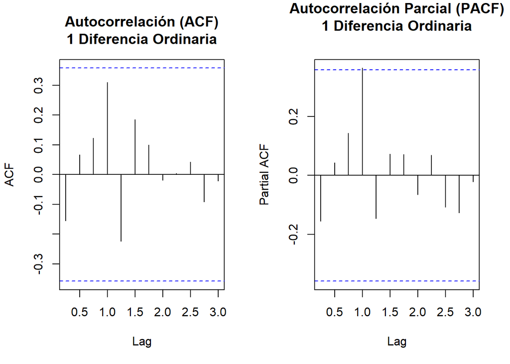

```r
serie_diferenciada1 <- diff(serie_log,lag=1,differences=1)

par(mfrow = c(1, 2))
acf( serie_diferenciada1,lag.max =12, main = "Autocorrelación (ACF)\n1 Diferencia Ordinaria")
pacf( serie_diferenciada1,lag.max =12, main = "Autocorrelación Parcial (PACF)\n1 Diferencia Ordinaria")
```

- La alternativa de una diferencia ordinaria aplicada a la serie transformada con logaritmo natural es la que menor desviación estándar genera, sin embargo, en este escenario no habría ningún valor significativo de autocorrelación para ningún orden de rezago, según se observa en los correlogramas (acumulado y parcial).

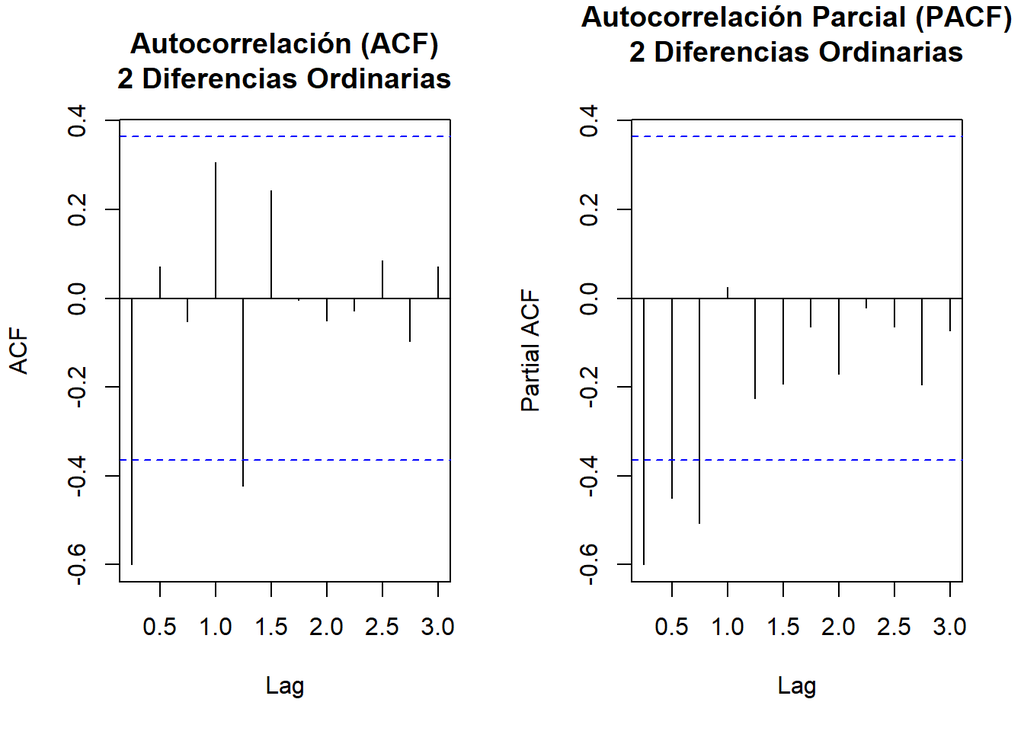

```r
serie_diferenciada2 <- diff(serie_log,lag=1,differences=2)

par(mfrow = c(1, 2))
acf( serie_diferenciada2,lag.max =12, main = "Autocorrelación (ACF)\n2 Diferencias Ordinarias")
pacf( serie_diferenciada2,lag.max =12, main = "Autocorrelación Parcial (PACF)\n2 Diferencias Ordinarias")
```

- La alternativa de dos diferencias ordinarias aplicadas a la serie transformada con logaritmo natural no es la que menor desviación estándar genera, sin embargo, en este escenario sí se encuentran valores de autocorrelación significativos según se observa en los correlogramas (general y parcial).
- Por esta razón, se trabajará con dos diferencias ordinarias en los modelos propuestos ($d = 2$ ).

### Modelos propuestos

A partir de los gráficos de ACF y PACF, se proponen los siguientes modelos a partir de la serie transformada con el logaritmo natural:

- Modelo 1: $SARIMA(0,2,1)(0,0,0)_4$

  $$(1-B)^2 X_t = (1 + \theta_1 B) a_t;~X_t = ln(Y_t)$$
- Modelo 2: $SARIMA(1,2,1)(0,0,0)_4$

  $$(1 - \phi_1 B) (1 - B)^2 X_t = (1 + \theta_1 B) a_t;~X_t = ln(Y_t)$$
- Modelo 3: $SARIMA(0,2,1)(0,1,1)_4$

  $$(1 - B)^2 (1 - B^4) X_t = (1 + \theta_1 B) (1 + \Theta_1 B^4) a_t;~X_t =
  ln(Y_t)$$
- Modelo autoarima

## Estimación de parámetros

Modelo 1:

$$(1-B)^2 X_t = (1 - 0.8695 B) a_t$$

- ✅:El intervalo de confianza para el coeficiente MA1 no incluye el valor cero, por lo que se concluye que el coeficiente `ma1=-0.8695` es estadísticamente significativo

```r
modelo1=arima(serie_log,order=c(0,2,1),
              seasonal=list(order=c(0,0,0),period=4))

modelo1
```

```
##
## Call:
## arima(x = serie_log, order = c(0, 2, 1), seasonal = list(order = c(0, 0, 0),
##     period = 4))
##
## Coefficients:
##           ma1
##       -0.8695
## s.e.   0.0879
##
## sigma^2 estimated as 0.001937:  log likelihood = 48.72,  aic = -95.44
```

```r
confint(modelo1)
```

```
##         2.5 %     97.5 %
## ma1 -1.041685 -0.6973007
```

Modelo 2:

$$(1 + 0.3019 B) (1 - B)^2 X_t = (1 -0.8048 B) a_t$$

- ❌El intervalo de confianza para el coeficiente AR1 sí incluye el valor cero, por lo que se concluye que el coeficiente `ar1=-0.3019` no es estadísticamente significativo.
- ✅El intervalo de confianza para el coeficiente MA1 no incluye el valor cero, por lo que se concluye que el coeficiente `ma1=-0.8048` es estadísticamente significativo.

```r
modelo2=arima(serie_log,order=c(1,2,1),
              seasonal=list(order=c(0,0,0),period=4))

modelo2
```

```
##
## Call:
## arima(x = serie_log, order = c(1, 2, 1), seasonal = list(order = c(0, 0, 0),
##     period = 4))
##
## Coefficients:
##           ar1      ma1
##       -0.3019  -0.8048
## s.e.   0.1866   0.1101
##
## sigma^2 estimated as 0.001776:  log likelihood = 49.89,  aic = -95.79
```

```r
confint(modelo2)
```

```
##          2.5 %      97.5 %
## ar1 -0.6676623  0.06385211
## ma1 -1.0204842 -0.58907002
```

Modelo 3:

$$(1 - B)^2 (1 - B^4) X_t = (1 - 0.986 B) (1 - 0.8832 B^4) a_t$$

- ✅El intervalo de confianza para el coeficiente MA1 no incluye el valor cero, por lo que se concluye que el coeficiente `ma1=-0.986` es estadísticamente significativo.
- ✅El intervalo de confianza para el coeficiente SMA1 no incluye el valor cero, por lo que se concluye que el coeficiente `sma1=-0.8832` es estadísticamente significativo.

```r
modelo3=arima(serie_log,order=c(0,2,1),
              seasonal=list(order=c(0,1,1),period=4))

modelo3
```

```
##
## Call:
## arima(x = serie_log, order = c(0, 2, 1), seasonal = list(order = c(0, 1, 1),
##     period = 4))
##
## Coefficients:
##           ma1     sma1
##       -0.9860  -0.8832
## s.e.   0.1688   0.4331
##
## sigma^2 estimated as 0.001768:  log likelihood = 35.12,  aic = -66.25
```

```r
confint(modelo3)
```

```
##          2.5 %      97.5 %
## ma1  -1.316912 -0.65505059
## sma1 -1.731964 -0.03441194
```

Modelo Autoarima:

$$(1-B)^2 X_t = (1 + \theta_1 B)(1 + \Theta_1 B^4) a_t$$

$$(1-B)^2 X_t = (1 - 0.9008 B)(1 + 0.3336 B^4) a_t$$

- ✅El intervalo de confianza para el coeficiente MA1 no incluye el valor cero, por lo que se concluye que el coeficiente `ma1=-0.9008` es estadísticamente significativo.
- ❌El intervalo de confianza para el coeficiente SMA1 sí incluye el valor cero, por lo que se concluye que el coeficiente `sma1=0.3336` no es estadísticamente significativo.

```r
library(forecast)

modelo_autoarima = auto.arima(serie_log)

modelo_autoarima
```

```
## Series: serie_log
## ARIMA(0,2,1)(0,0,1)[4]
##
## Coefficients:
##           ma1    sma1
##       -0.9008  0.3336
## s.e.   0.0912  0.1825
##
## sigma^2 = 0.001862:  log likelihood = 50.17
## AIC=-94.33   AICc=-93.37   BIC=-90.23
```

```r
confint(modelo_autoarima)
```

```
##            2.5 %     97.5 %
## ma1  -1.07949091 -0.7220623
## sma1 -0.02420002  0.6913715
```

A continuación se muestra un cuadro resumen con los valores de los criterios de información de cada modelo:

*Resumen criterios de información*

| Modelo | Log-Likelihood | AIC | BIC |
| --- | --- | --- | --- |
| Modelo 1: $SARIMA(0,2,1)(0,0,0)_4$ | 48.71801 | -95.44 | -90.70143 |
| Modelo 2: $SARIMA(1,2,1)(0,0,0)_4$ | 49.89493 | -95.79 | -89.68798 |
| Modelo 3: $SARIMA(0,2,1)(0,1,1)_4$ | 35.12435 | -66.25 | -60.59207 |
| Modelo Autoarima: $ARIMA(0,2,1)(0,0,1)_4$ | 50.16655 | -94.33 | -90.23 |

- De acuerdo con esta información, el modelo con los mejores valores es el N° 2, ya que tiene los menores valores de AIC (-95.79) y y un valor relativamente alto del estadístico log-likelihood (49.89).
- Vale la pena señalar que, a excepción del modelo 3, los valores de los criterios de información son muy similares.

## Verificación supuestos sobre residuales

```r
modelosentrenados <- list(
  "Modelo 1" = modelo1,
  "Modelo 2" = modelo2,
  "Modelo 3" = modelo3,
  "Auto-ARIMA" = modelo_autoarima
)
```

### Media = 0

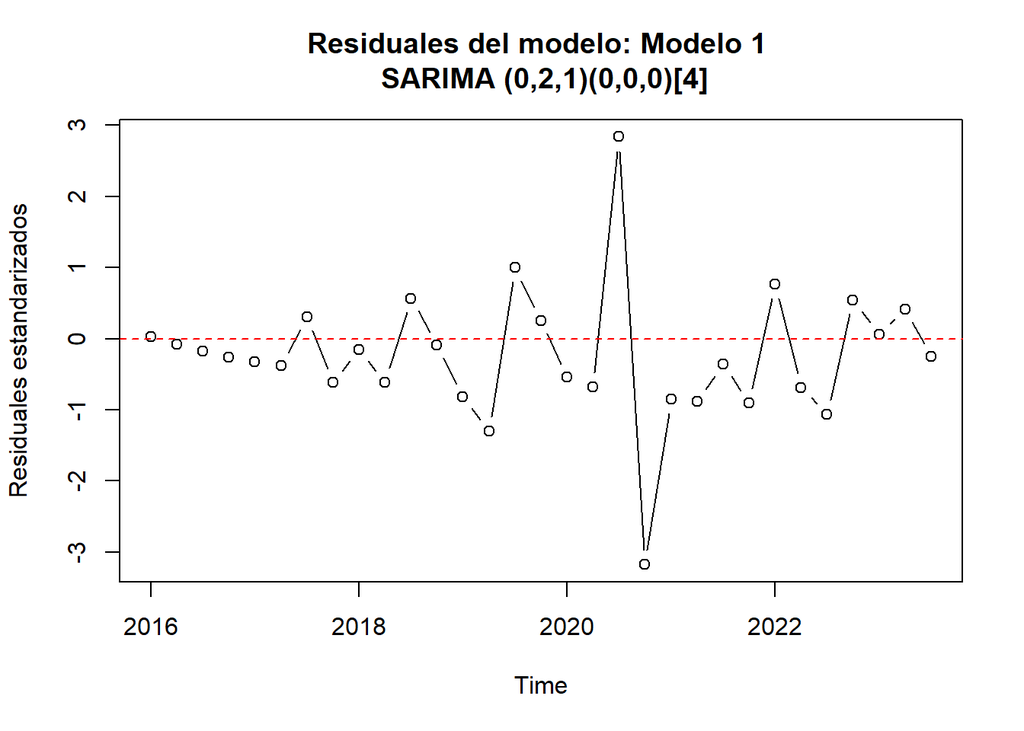

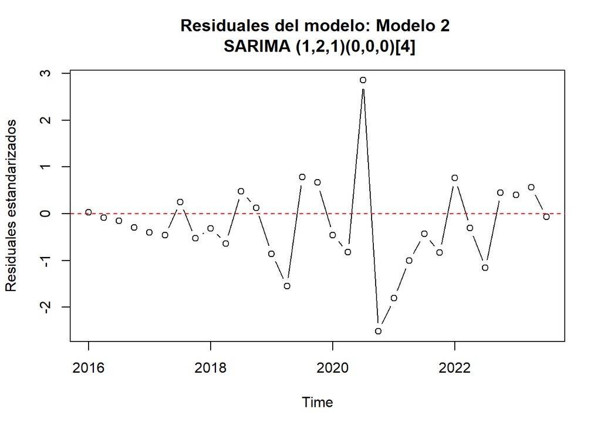

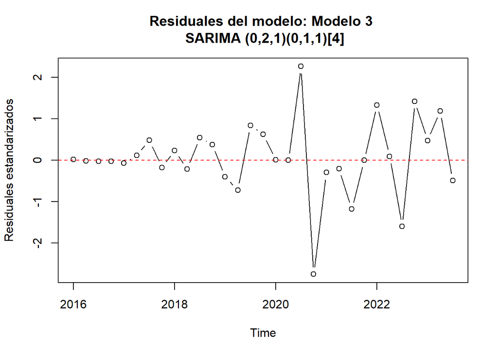

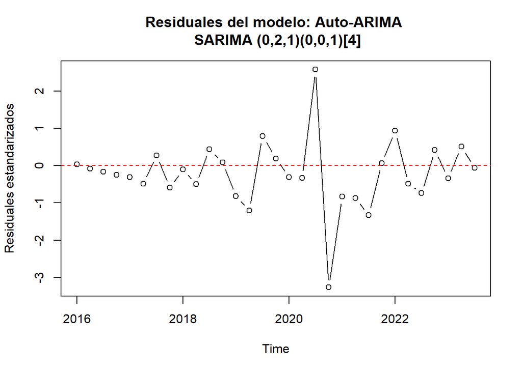

```r
for (i in seq_along(modelosentrenados)) {

  # 1. Extraer el vector de órdenes
  # El orden en $arma es: [p, q, P, Q, s, d, D]
  o <- modelosentrenados[[i]]$arma

  # 2. Construir la etiqueta de los órdenes
  # Formato: (p,d,q)(P,D,Q)[s]
  orden_txt <- paste0("(", o[1], ",", o[6], ",", o[2], ")",
                      "(", o[3], ",", o[7], ",", o[4], ")[", o[5], "]")

  # 3. Generar el gráfico con título dinámico
  residuos <- rstandard(modelosentrenados[[i]])

  plot(residuos,
       ylab = 'Residuales estandarizados',
       type = 'b',
       main = paste("Residuales del modelo:", names(modelosentrenados)[i], "\n SARIMA", orden_txt))

  abline(h = 0, col = "red", lty = 2)
}
```

- De acuerdo con el criterio gráfico, los residuales de todos los cuatro modelos estimados oscilan alrededor del cero. Esto significa que los residuales no muestran patrones que el modelo dejó de calcular.

```r
#Para ver si tienen media cero creamos un intervalo de confianza bajo la hipotesis nula
#haga una prueba t para la media

for (i in seq_along(modelosentrenados)) {
  cat("\n--- Análisis de Residuos:", names(modelosentrenados)[i], "---\n")

  # Usamos residuals() por seguridad y print() para ver el resultado
  print(t.test(residuals(modelosentrenados[[i]])))
}
```

```
##
## --- Análisis de Residuos: Modelo 1 ---
##
##  One Sample t-test
##
## data:  residuals(modelosentrenados[[i]])
## t = -1.3936, df = 30, p-value = 0.1737
## alternative hypothesis: true mean is not equal to 0
## 95 percent confidence interval:
##  -0.025885210  0.004886653
## sample estimates:
##   mean of x
## -0.01049928
##
##
## --- Análisis de Residuos: Modelo 2 ---
##
##  One Sample t-test
##
## data:  residuals(modelosentrenados[[i]])
## t = -1.3804, df = 30, p-value = 0.1777
## alternative hypothesis: true mean is not equal to 0
## 95 percent confidence interval:
##  -0.024704983  0.004777249
## sample estimates:
##    mean of x
## -0.009963867
##
##
## --- Análisis de Residuos: Modelo 3 ---
##
##  One Sample t-test
##
## data:  residuals(modelosentrenados[[i]])
## t = 0.36609, df = 30, p-value = 0.7169
## alternative hypothesis: true mean is not equal to 0
## 95 percent confidence interval:
##  -0.01153163  0.01656873
## sample estimates:
##   mean of x
## 0.002518549
##
##
## --- Análisis de Residuos: Auto-ARIMA ---
##
##  One Sample t-test
##
## data:  residuals(modelosentrenados[[i]])
## t = -1.3212, df = 30, p-value = 0.1964
## alternative hypothesis: true mean is not equal to 0
## 95 percent confidence interval:
##  -0.024042125  0.005154214
## sample estimates:
##    mean of x
## -0.009443956
```

- Los p-valores de la prueba t-student para los cuatro modelos son mayores que 0.05, por lo que no es posible rechazar la hipótesis nula (media = 0). Adicionalmente, los intervalos de confianza para los cuatro modelos incluyen el valor 0.
- Por lo tanto, se puede concluir que todos los cuatro modelos estimados cumplen con el supuesto de tener una media igual a cero.

### Varianza Constante

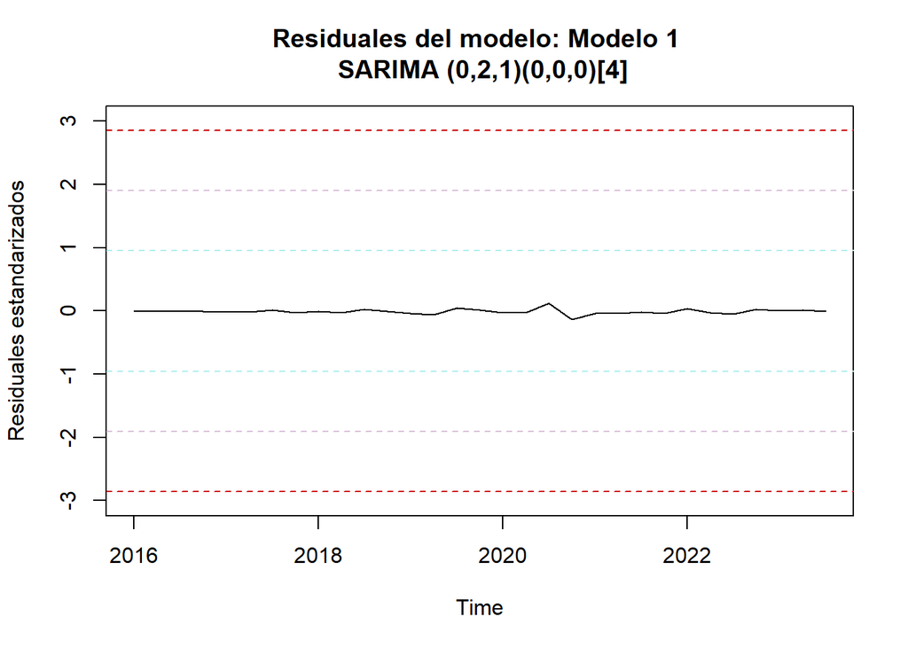

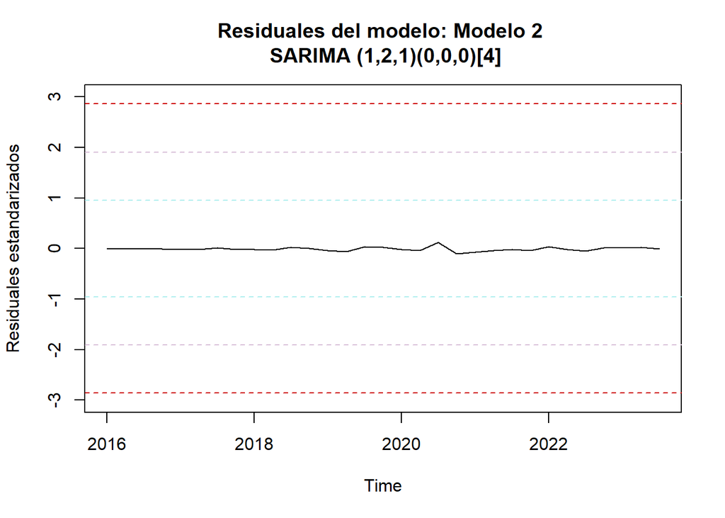

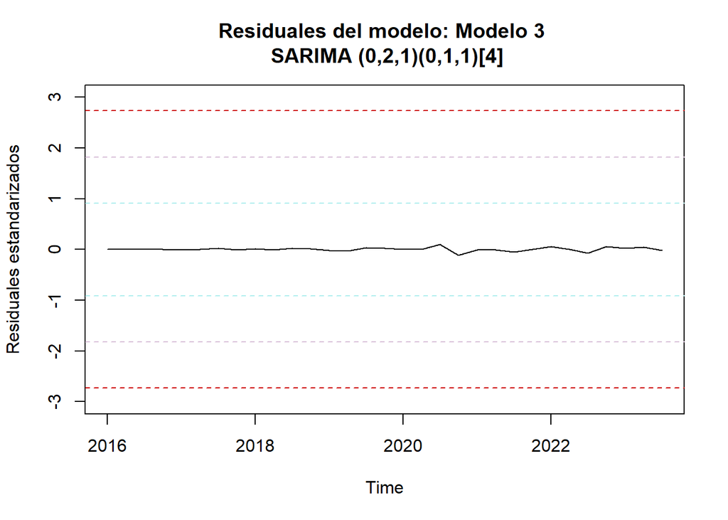

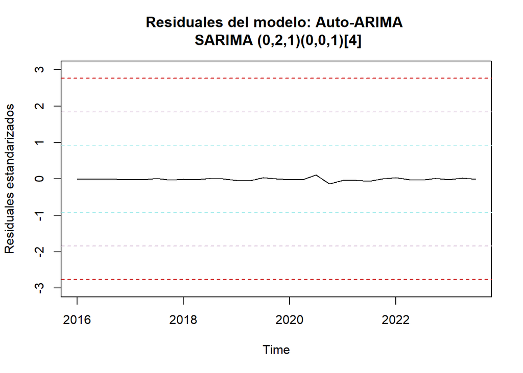

```r
for (i in seq_along(modelosentrenados)) {

  # 1. Extraer el vector de órdenes
  # El orden en $arma es: [p, q, P, Q, s, d, D]
  o <- modelosentrenados[[i]]$arma

  # 2. Construir la etiqueta de los órdenes
  # Formato: (p,d,q)(P,D,Q)[s]
  orden_txt <- paste0("(", o[1], ",", o[6], ",", o[2], ")",
                      "(", o[3], ",", o[7], ",", o[4], ")[", o[5], "]")

  # 3. Gráfico con título dinámico
  a=sd(rstandard(modelosentrenados[[i]]))
  #Para ver si tiene varianza constante, observe la grafica
  plot(modelosentrenados[[i]]$residuals, ylim=c(-3,3), main = paste("Residuales del modelo:", names(modelosentrenados)[i], "\n SARIMA", orden_txt), ylab = 'Residuales estandarizados')

  #Simula una franja de 3 desviaciones estándar-> valores extremos
  abline(h=-3*a,  col = "red3", lty=2)
  abline(h=+3*a,  col = "red3", lty=2)

  #Simula una franja de 2 desviaciones estándar
  abline(h=-2*a,  col = "thistle", lty=2)
  abline(h=+2*a,  col = "thistle", lty=2)

  #Simula una franja de 1 desviación estándar
  abline(h=-1*a,  col = "paleturquoise2", lty=2)
  abline(h=+1*a,  col = "paleturquoise2", lty=2)

}
```